# MG205: Econometrics Theory and Applications

Topic 9: Instrumental Variables

José Ignacio González Rojas

j.i.gonzalez-rojas@lse.ac.uk

London School of Economics and Political Science

## Last Week: DiD Exploits Variation Across Groups and Time

### Recap and Bridge

#### Last Week

- FD/FE eliminate **time-invariant** omitted variable bias
- DiD exploits variation across **groups** and **time**
- Parallel trends assumption: untreated units track counterfactual

#### Today

- When panel data and DiD **cannot** solve endogeneity
- The **Instrumental Variables** approach
- Finding exogenous variation in an endogenous regressor

## Endogeneity Persists When Panel Data Is Not Enough

### Four Sources

#### The Problem

- $\text{Cov}(x_{i}, e_{i}) \neq 0$
- OLS is **biased** and **inconsistent**
- The bias does not shrink as the sample grows

#### When Panel Data Fails

- Time-varying omitted variables
- Simultaneity (reverse causation)
- Dynamic feedback between $x_{it}$ and $e_{it}$
- Measurement error in the regressor

Today we introduce a fundamentally different strategy: exploit an external source of variation.

## An Instrument Isolates Exogenous Variation in the Regressor

### The IV Strategy

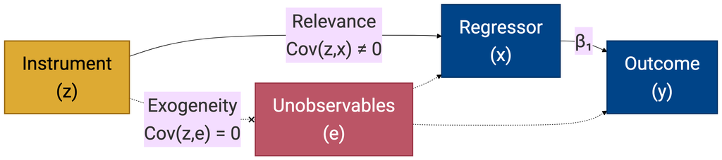

- The instrument $z_{i}$ shifts $x_{i}$ but has **no direct path** to $y_{i}$
- We use only the variation in $x_{i}$ that comes from $z_{i}$
- This isolates the exogenous component, breaking the link to $e_{i}$

## Two Conditions Define a Valid Instrument

### Relevance and Exogeneity

#### Relevance

- $\text{Cov}(z_{i}, x_{i}) \neq 0$
- The instrument must **predict** the regressor
- **Testable**: F-statistic in the first stage
- Rule of thumb: $F > 10$

#### Exogeneity

- $\text{Cov}(z_{i}, e_{i}) = 0$
- The instrument must be **uncorrelated** with unobservables
- **Generally untestable** — requires an economic argument

## 2SLS with One Endogenous Regressor and Exogenous Controls

### The General Case

#### The structural model

$$y_{i} = \beta_{0} + \beta_{1} x_{i} + \beta_{2} w_{i} + e_{i}$$

where $x_{i}$ is endogenous ($\text{Cov}(x_{i}, e_{i}) \neq 0$) and $w_{i}$ is exogenous ($\text{Cov}(w_{i}, e_{i}) = 0$).

#### First Stage — include ALL exogenous variables

$$x_{i} = \gamma_{0} + \gamma_{1} z_{i} + \gamma_{2} w_{i} + v_{i}$$

#### Second Stage — replace $x_{i}$ with $\hat{x}_{i}$, keep controls

$$y_{i} = \beta_{0} + \beta_{1} \hat{x}_{i} + \beta_{2} w_{i} + \xi_{i}$$

## Exogenous Controls Must Appear in Both Stages

### A Common Mistake

- Omitting $w_{i}$ from the first stage biases $\hat{x}_{i}$
- The predicted values $\hat{x}_{i}$ would absorb variation from $w_{i}$, contaminating the second stage
- **Rule:** every exogenous variable in the structural model goes into the first stage too

## 2SLS Simplifies to a Ratio When There Are No Controls

### The Simple Case

#### Without controls

$$\hat{\beta}_{1}^{\text{TSLS}} = \frac{\text{Cov}(z_{i},\, y_{i})}{\text{Cov}(z_{i},\, x_{i})}$$

- Reduced form: $y_{i}$ on $z_{i}$
- First stage: $x_{i}$ on $z_{i}$
- $\beta_{1}$ = ratio of the two coefficients

#### With controls

- Same logic, but **partial** out $w_{i}$ first
- Software handles this automatically
- The ratio interpretation still holds, using **partial** covariances

TSLS is consistent when instruments are valid. It is, however, biased in finite samples.

## Relevance Requires an F-Test, Not a t-Test

### Why We Test Joint Significance

**With one instrument**

- F-test on $\gamma_{1}$ is equivalent to $t^{2}$ — both give the same answer

**With multiple instruments** $z_{1i}$, $z_{2i}$

- Each instrument might be **individually** weak ($t < 2$)
- But **jointly**, they may predict $x_{i}$ well ($F > 10$)
- The F-test captures **joint** predictive power — individual t-tests miss this

# **Exercise 1:** PC Ownership and College Admissions Scores

## Owning a PC May Improve Test Scores, but Correlation Is Not Causation

### Setting and Research Question

#### The Model

$$\text{score}_{i} = \beta_{0} + \beta_{1}\;\mathbb{1}[\text{has PC}_{i}] + e_{i}$$

- $\beta_{1}$ is the causal effect of PC ownership on test scores
- OLS is biased if PC ownership is endogenous

#### Why PC Is Endogenous

The error $e_{i}$ captures unobservables correlated with PC ownership:

- Socioeconomic status
- Family income
- Parental education
- Student motivation

All in $e_{i}$ **and** correlated with PC $\Rightarrow$ $\text{Cov}(x_{i}, e_{i}) \neq 0$

## Family Income Fails as an Instrument, but a Random Grant Succeeds

### Testing the Two Conditions

#### Family Income ✗

| Condition | Status |
| --- | --- |
| Relevance | ✓ Correlated with PC ownership |
| Exogeneity | ✗ Directly affects scores |

Family income belongs **in the regression as a control**, not as an instrument.

#### Random Grant ✓

| Condition | Status |
| --- | --- |
| Relevance | ✓ Increases PC ownership |
| Exogeneity | ✓ Randomly assigned |

Random assignment severs any link between the grant and unobservables.

Family income is a control variable, not an instrument.

## The Grant Identifies the Causal Effect Through 2SLS

### First Stage and Second Stage

#### First Stage

$$\mathbb{1}[\text{has PC}_{i}] = \gamma_{0} + \gamma_{1}\;\mathbb{1}[\text{got grant}_{i}] + v_{i}$$

- $\hat{\gamma}_{1}$: how much does receiving the grant raise PC ownership?
- Compute $\widehat{\mathbb{1}[\text{has PC}]}_{i}$

#### Second Stage

$$\text{score}_{i} = \beta_{0} + \beta_{1}\;\widehat{\mathbb{1}[\text{has PC}]}_{i} + \xi_{i}$$

- $\hat{\beta}_{1}$ is the TSLS estimate of the causal effect

Not all grant recipients purchase a PC; some non-recipients already own one. The instrument shifts ownership **at the margin**.

# **Exercise 2:** School Choice Programmes and Test Performance

## Self-Selection into Choice Schools Creates Endogeneity

### Setting and Research Question

#### The Model

$$\text{score}_{i} = \beta_{0} + \beta_{1}\;\mathbb{1}[\text{choice}_{i}] + \beta_{2}\;\text{family income}_{i} + e_{i}$$

- $\mathbb{1}[\text{choice}_{i}]$ is endogenous: motivated families **self-select** into choice schools
- $\text{Cov}(\mathbb{1}[\text{choice}_{i}], e_{i}) \neq 0$ even after controlling for family income
- Family income is **exogenous** — it belongs in the model as a control

#### The Instrument

- **Grant amounts** randomly assigned **within income class**
- Conditional on income, the grant is uncorrelated with $e_{i}$

## The Three Regressions of IV

### OLS, First Stage, and Reduced Form

#### OLS (biased)

$$\text{score}_{i} = \beta_{0} + \beta_{1}\;\mathbb{1}[\text{choice}_{i}] + \beta_{2}\;\text{family income}_{i} + e_{i}$$

#### First Stage — all exogenous variables on the right-hand side

$$\mathbb{1}[\text{choice}_{i}] = \gamma_{0} + \gamma_{1}\;\text{family income}_{i} + \gamma_{2}\;\mathbb{1}[\text{grant}_{i}] + v_{i}$$

- Need $\gamma_{2} \neq 0$: test with F-statistic on $\mathbb{1}[\text{grant}_{i}]$

## The Second Stage Recovers the Causal Effect of Choice

### Structural Parameter

#### Second Stage — replace $\mathbb{1}[\text{choice}_{i}]$ with $\widehat{\mathbb{1}[\text{choice}]}_{i}$, keep controls

$$\text{score}_{i} = \beta_{0} + \beta_{1}\;\widehat{\mathbb{1}[\text{choice}]}_{i} + \beta_{2}\;\text{family income}_{i} + \xi_{i}$$

- $\hat{\beta}_{1}$: causal effect of **attending a choice school** on scores
- Family income appears in **both** stages — exogenous controls always included

## The Reduced Form Captures the Grant Effect

### Policy Parameter

#### Reduced Form — regress outcome directly on exogenous variables

$$\text{score}_{i} = \alpha_{0} + \alpha_{1}\;\text{family income}_{i} + \alpha_{2}\;\mathbb{1}[\text{grant}_{i}] + u_{i}$$

- $\alpha_{2}$: causal effect of the **grant** on scores (policy-relevant)
- Structural parameter: $\beta_{1} = \alpha_{2} / \gamma_{2}$
- The reduced form answers a policy question; the structural model answers a causal question

# **Exercise 3:** NHS Resources and Mortality Rates

## More Doctors Reduce Mortality, but OLS Cannot Show This

### Setting and Research Question

#### The Setting

In 2005, the Department of Health randomly selected NHS Trusts to receive extra resources for hiring additional doctors and nurses.

#### The Structural Model (OLS fails)

$$\text{mortality}_{i} = \beta_{0} + \beta_{1}\;\text{doctors}_{i} + e_{i}$$

- $\text{doctors}_{i}$ is endogenous: regions with sicker populations hire more doctors
- $\text{Cov}(\text{doctors}_{i}, e_{i}) \neq 0$ $\Rightarrow$ OLS biased

#### The Instrument

- $\mathbb{1}[\text{chosen}_{i}]$: randomly selected by the Department of Health
- **Relevance:** chosen trusts hire more doctors
- **Exogeneity:** random selection $\Rightarrow$ uncorrelated with $e_{i}$

## The Reduced Form Captures the Programme Effect

### Policy Parameter

#### Reduced Form (OLS is valid — random assignment)

$$\widehat{\text{mortality}}_{i} = \underset{(1)}{2} - \underset{(1)}{3}\;\mathbb{1}[\text{chosen}_{i}]$$

- Being chosen reduces mortality by 3 units
- This is the effect of **the programme**, not of one extra doctor
- The reduced form answers: “what happens if a region is selected?”

## The Structural Model Recovers the Effect per Doctor

### Causal Parameter

#### First Stage

$$\text{doctors}_{i} = \pi_{0} + \pi_{1}\;\mathbb{1}[\text{chosen}_{i}] + v_{i}$$

#### Second Stage

$$\text{mortality}_{i} = \beta_{0} + \beta_{1}\;\widehat{\text{doctors}}_{i} + \xi_{i}$$

- $\hat{\beta}_{1}^{\text{TSLS}}$: effect of **one additional doctor** on mortality

# **Exercise 4:** Testing Whether Instruments Are Valid

## Relevance Is Testable but Exogeneity Is Not

### Testing the Two Conditions

#### Relevance — Testable

1. Regress $x_{i}$ on $z_{1i}$, $z_{2i}$ (and any controls)
2. F-test for **joint** significance of instruments
3. Rule of thumb: **$F > 10$**
4. Low $F$ $\Rightarrow$ weak instruments $\Rightarrow$ TSLS unreliable

#### Exogeneity — Untestable

- $e_{i}$ is unobserved $\Rightarrow$ **cannot** directly test $\text{Cov}(z_{i}, e_{i}) = 0$
- Requires economic argument
- **Partial test** when overidentified (more instruments than endogenous regressors)

## Why the F-Test and Not Individual t-Tests

### Joint vs Individual Significance

#### The Problem with t-Tests

- With **two instruments** $z_{1}$ and $z_{2}$:
  - $t$-test on $\gamma_{1}$: is $z_{1}$ significant?
  - $t$-test on $\gamma_{2}$: is $z_{2}$ significant?
- Each could be insignificant individually
- But **together** they may predict $x_{i}$ well

#### The F-Test Solution

- Tests $H_{0}: \gamma_{1} = \gamma_{2} = 0$ **jointly**
- Captures combined predictive power
- With **one** instrument: $F = t^{2}$ (equivalent)
- With **multiple** instruments: F-test is strictly more informative

Always report the first-stage F-statistic. Individual t-statistics on instruments are not sufficient.

## Overidentification Provides a Partial Test of Exogeneity

### Comparing Estimates Across Instruments

With two instruments $z_{1}$ and $z_{2}$ for one endogenous regressor:

- Estimate with **$z_{1}$ alone** $\Rightarrow$ $\hat{\beta}_{1}$
- Estimate with **$z_{2}$ alone** $\Rightarrow$ $\hat{\beta}_{2}$
- Estimate with **both** $\Rightarrow$ $\hat{\beta}_{\text{both}}$

If all three estimates are **similar** $\Rightarrow$ consistent with both instruments being valid.

If estimates **differ significantly** $\Rightarrow$ at least one instrument is invalid.

This is the logic behind the **Sargan–Hansen overidentification test**.

# **Exercise 5:** Peer Effects on Criminal Behaviour

## A Criminal’s Decision to Go Legit Depends on His Friends

### Setting and Research Question

#### The Setting

**Syldavia.** Young male criminals sometimes decide to “go legit” and join the law-abiding population.

- **Study 1:** Favourable economic conditions increase the likelihood of going legit
- **Study 2:** Having a **son** (rather than a daughter) increases the likelihood of going legit

#### The Research Question

Does a criminal’s **best friend** going legit make him more likely to go legit too?

- $\mathbb{1}[\text{legit}_{i}] = 1$ if criminal $i$ goes legit
- $\mathbb{1}[\text{friendlegit}_{i}] = 1$ if his best friend goes legit

## OLS Cannot Identify Peer Effects Because of Shared Shocks

### The Endogeneity Problem

#### OLS (biased)

$$\widehat{\mathbb{1}[\text{legit}]}_{i} = \underset{(0.09)}{0.25} + \underset{(0.12)}{0.33}\;\mathbb{1}[\text{friendlegit}_{i}]$$

- Economic conditions are in $e_{i}$ (Study 1 found they matter)
- Economic conditions also affect the friend’s decision
- $\text{Cov}(\mathbb{1}[\text{friendlegit}_{i}], e_{i}) \neq 0$ $\Rightarrow$ OLS is biased upward
- The 0.33 coefficient captures **both** the peer effect and common shocks

## The Gender of a Friend’s Child Provides Exogenous Variation

### The IV Strategy

**Proposed instrument:** $\mathbb{1}[\text{friend has son}_{i}]$

| Condition | Argument |
| --- | --- |
| **Relevance** | Study 2: sons $\Rightarrow$ friend more likely to go legit $\Rightarrow$ predicts $\mathbb{1}[\text{friendlegit}_{i}]$ |
| **Exogeneity** | Child gender is biologically random $\Rightarrow$ uncorrelated with $e_{i}$ |

## The Two Stages Recover the Causal Peer Effect

### First Stage and Second Stage

#### First Stage

$$\mathbb{1}[\text{friendlegit}_{i}] = \gamma_{0} + \gamma_{1}\;\mathbb{1}[\text{friend has son}_{i}] + v_{i}$$

#### Second Stage

$$\mathbb{1}[\text{legit}_{i}] = \beta_{0} + \beta_{1}\;\widehat{\mathbb{1}[\text{friendlegit}]}_{i} + \xi_{i}$$

- $\hat{\beta}_{1}^{\text{TSLS}}$: the causal effect of a friend going legit
- We use only the variation driven by whether the friend has a son

# Summary

## IV Exploits Exogenous Variation to Overcome Endogeneity

### Summary

1. **IV solves endogeneity** when panel data and DiD cannot — by finding variation in $x_{i}$ unrelated to $e_{i}$
2. **Valid instruments** require *relevance* (testable via F-statistic) and *exogeneity* (untestable in general)
3. **Exogenous controls** must appear in **both** the first and second stages
4. **Always use the F-test** (not individual t-tests) to assess instrument strength — rule of thumb $F > 10$
5. **The reduced form** answers a policy question; **the structural model** answers a causal question

## Next Week: Empirical Exercise 7

### Revolving Door Lobbyists

- **Paper:** Blanes i Vidal, Draca & Fons-Rosen (2012) — “Revolving Door Lobbyists”
- Do political connections drive lobbying revenue, or is it expertise?
- Identification: what happens to a lobbyist’s revenue when their connected politician **exits Congress**?
- Panel data with individual fixed effects, event-study design